# Association rules

INSOFE Lab

28 July, 2018

## Data preprocessing

Clearing environment variables

```r
rm(list=ls(all=TRUE))
```

Loading required libraries

```r
# install.packages('arules')
library(arules)
```

Data loading

```r
data("Groceries")
Groceries
```

```
## transactions in sparse format with
##  9835 transactions (rows) and
##  169 items (columns)
```

```r
head(Groceries)
```

```
## transactions in sparse format with
##  6 transactions (rows) and
##  169 items (columns)
```

```r
# Groceries <- read.transactions(file.choose())     # Read transactions from file

# Writing Groceries Transaction data to csv file
# Groceries_new <- as(Groceries,"data.frame")
# write.csv(Groceries_new, file = "Groceries.csv",row.names = TRUE)
```

Viewing the data

```r
# Groceries@itemInfo
inspect(Groceries[1:10])
```

```
##      items
## [1]  {citrus fruit,
##       semi-finished bread,
##       margarine,
##       ready soups}
## [2]  {tropical fruit,
##       yogurt,
##       coffee}
## [3]  {whole milk}
## [4]  {pip fruit,
##       yogurt,
##       cream cheese ,
##       meat spreads}
## [5]  {other vegetables,
##       whole milk,
##       condensed milk,
##       long life bakery product}
## [6]  {whole milk,
##       butter,
##       yogurt,
##       rice,
##       abrasive cleaner}
## [7]  {rolls/buns}
## [8]  {other vegetables,
##       UHT-milk,
##       rolls/buns,
##       bottled beer,
##       liquor (appetizer)}
## [9]  {pot plants}
## [10] {whole milk,
##       cereals}
```

Summarizing the data in transaction table

```r
summary(Groceries)
```

```
## transactions as itemMatrix in sparse format with
##  9835 rows (elements/itemsets/transactions) and
##  169 columns (items) and a density of 0.02609146
##
## most frequent items:
##       whole milk other vegetables       rolls/buns             soda
##             2513             1903             1809             1715
##           yogurt          (Other)
##             1372            34055
##
## element (itemset/transaction) length distribution:
## sizes
##    1    2    3    4    5    6    7    8    9   10   11   12   13   14   15
## 2159 1643 1299 1005  855  645  545  438  350  246  182  117   78   77   55
##   16   17   18   19   20   21   22   23   24   26   27   28   29   32
##   46   29   14   14    9   11    4    6    1    1    1    1    3    1
##
##    Min. 1st Qu.  Median    Mean 3rd Qu.    Max.
##   1.000   2.000   3.000   4.409   6.000  32.000
##
## includes extended item information - examples:
##        labels  level2           level1
## 1 frankfurter sausage meat and sausage
## 2     sausage sausage meat and sausage
## 3  liver loaf sausage meat and sausage
```

Looking at the item frequency

```r
itemFrequency(x = Groceries, type = "absolute")
```

```
##               frankfurter                   sausage
##                       580                       924
##                liver loaf                       ham
##                        50                       256
##                      meat         finished products
##                       254                        64
##           organic sausage                   chicken
##                        22                       422
##                    turkey                      pork
##                        80                       567
##                      beef            hamburger meat
##                       516                       327
##                      fish              citrus fruit
##                        29                       814
##            tropical fruit                 pip fruit
##                      1032                       744
##                    grapes                   berries
##                       220                       327
##               nuts/prunes           root vegetables
##                        33                      1072
##                    onions                     herbs
##                       305                       160
##          other vegetables packaged fruit/vegetables
##                      1903                       128
##                whole milk                    butter
##                      2513                       545
##                      curd                   dessert
##                       524                       365
##               butter milk                    yogurt
##                       275                      1372
##        whipped/sour cream                 beverages
##                       705                       256
##                  UHT-milk            condensed milk
##                       329                       101
##                     cream               soft cheese
##                        13                       168
##             sliced cheese               hard cheese
##                       241                       241
##             cream cheese           processed cheese
##                       390                       163
```

[output cut: 115 more lines]

```
##                        27                         4
##           cling film/bags            kitchen towels
##                       112                        59
##    house keeping products                   candles
##                        82                        88
##               light bulbs      sound storage medium
##                        41                         1
##                newspapers                photo/film
##                       785                        91
##                pot plants    flower soil/fertilizer
##                       170                        19
##            flower (seeds)             shopping bags
##                       102                       969
##                      bags
##                         4
```

```r
itemFrequency(x = Groceries, type = "relative")
```

```
##               frankfurter                   sausage
##              0.0589730554              0.0939501779
##                liver loaf                       ham
##              0.0050838841              0.0260294865
##                      meat         finished products
##              0.0258261312              0.0065073716
##           organic sausage                   chicken
##              0.0022369090              0.0429079817
##                    turkey                      pork
##              0.0081342145              0.0576512456
##                      beef            hamburger meat
##              0.0524656838              0.0332486019
##                      fish              citrus fruit
##              0.0029486528              0.0827656329
##            tropical fruit                 pip fruit
##              0.1049313676              0.0756481952
##                    grapes                   berries
##              0.0223690900              0.0332486019
##               nuts/prunes           root vegetables
##              0.0033553635              0.1089984748
##                    onions                     herbs
##              0.0310116929              0.0162684291
##          other vegetables packaged fruit/vegetables
##              0.1934926284              0.0130147433
##                whole milk                    butter
##              0.2555160142              0.0554143366
##                      curd                   dessert
##              0.0532791052              0.0371123538
##               butter milk                    yogurt
##              0.0279613625              0.1395017794
##        whipped/sour cream                 beverages
##              0.0716827656              0.0260294865
##                  UHT-milk            condensed milk
##              0.0334519573              0.0102694459
##                     cream               soft cheese
##              0.0013218099              0.0170818505
##             sliced cheese               hard cheese
##              0.0245043213              0.0245043213
##             cream cheese           processed cheese
##              0.0396542959              0.0165734621
```

[output cut: 115 more lines]

```
##              0.0027452974              0.0004067107
##           cling film/bags            kitchen towels
##              0.0113879004              0.0059989832
##    house keeping products                   candles
##              0.0083375699              0.0089476360
##               light bulbs      sound storage medium
##              0.0041687850              0.0001016777
##                newspapers                photo/film
##              0.0798169802              0.0092526690
##                pot plants    flower soil/fertilizer
##              0.0172852059              0.0019318760
##            flower (seeds)             shopping bags
##              0.0103711235              0.0985256736
##                      bags
##              0.0004067107
```

Plotting the item frequency for top 15 items

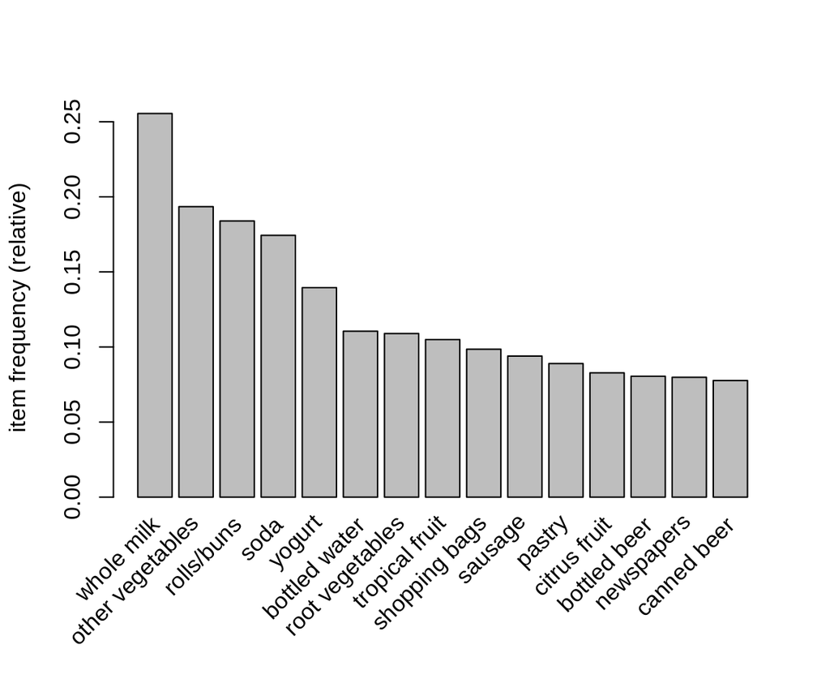

```r
itemFrequencyPlot(x = Groceries, topN = 15, type="relative")
```

## Mining rules/pattern

You will always have to pass the minimum required support/confidence or both

We set the minimum support to 0.001 and minimum confidence of 0.8

Get the rules :

```r
rules <- apriori(Groceries, parameter = list(supp = 0.001, conf = 0.8), control = list(verbose = F))
length(rules)
```

```
## [1] 410
```

Inspecting top 5 rules by rounding off all the numerical values to 2 digits in the output

```r
getOption("digits")
```

```
## [1] 7
```

```r
options(digits = 2)
inspect(rules[1:5])
```

```
##     lhs                        rhs            support confidence lift
## [1] {liquor,red/blush wine} => {bottled beer} 0.0019  0.90       11.2
## [2] {curd,cereals}          => {whole milk}   0.0010  0.91        3.6
## [3] {yogurt,cereals}        => {whole milk}   0.0017  0.81        3.2
## [4] {butter,jam}            => {whole milk}   0.0010  0.83        3.3
## [5] {soups,bottled beer}    => {whole milk}   0.0011  0.92        3.6
##     count
## [1] 19
## [2] 10
## [3] 17
## [4] 10
## [5] 11
```

Reading the pattern is now easier. for e.g. : If someone buys yogurt and cereals, they are 81% likely to buy Whole milk too.

We can get summary information about the rules that give us some interesting information such as: * The number of rules generated: 410 * The distribution of rules by length: Most rules are 4 items long * The summary of quality measures: interesting to see ranges of support, lift, and confidence. * The information on the data mined: total data mined, and minimum parameters.

```r
summary(rules)
```

```
## set of 410 rules
##
## rule length distribution (lhs + rhs):sizes
##   3   4   5   6
##  29 229 140  12
##
##    Min. 1st Qu.  Median    Mean 3rd Qu.    Max.
##     3.0     4.0     4.0     4.3     5.0     6.0
##
## summary of quality measures:
##     support          confidence        lift          count
##  Min.   :0.00102   Min.   :0.80   Min.   : 3.1   Min.   :10.0
##  1st Qu.:0.00102   1st Qu.:0.83   1st Qu.: 3.3   1st Qu.:10.0
##  Median :0.00122   Median :0.85   Median : 3.6   Median :12.0
##  Mean   :0.00125   Mean   :0.87   Mean   : 4.0   Mean   :12.3
##  3rd Qu.:0.00132   3rd Qu.:0.91   3rd Qu.: 4.3   3rd Qu.:13.0
##  Max.   :0.00315   Max.   :1.00   Max.   :11.2   Max.   :31.0
##
## mining info:
##       data ntransactions support confidence
##  Groceries          9835   0.001        0.8
```

when we have large set of rules then we would prefer to sort the rules based on requirement and take decision using top rules

Let’s say we wanted to have the most likely rules, we can easily sort out the rules by confidence in descending order by using following piece of code

```r
sorted_rules <- sort(rules, by = "confidence" ,decreasing = T)
inspect(sorted_rules[1:5])
```

```
##     lhs                     rhs          support confidence lift count
## [1] {rice,
##      sugar}              => {whole milk}  0.0012          1  3.9    12
## [2] {canned fish,
##      hygiene articles}   => {whole milk}  0.0011          1  3.9    11
## [3] {root vegetables,
##      butter,
##      rice}               => {whole milk}  0.0010          1  3.9    10
## [4] {root vegetables,
##      whipped/sour cream,
##      flour}              => {whole milk}  0.0017          1  3.9    17
## [5] {butter,
##      soft cheese,
##      domestic eggs}      => {whole milk}  0.0010          1  3.9    10
```

## Visualization

- Visualizing the rules using a graph

```r
sorted_rules <- sort(rules, by = "support" ,decreasing = T)
inspect(sorted_rules[1:5])
```

```
##     lhs                   rhs                support confidence lift count
## [1] {citrus fruit,
##      tropical fruit,
##      root vegetables,
##      whole milk}       => {other vegetables}  0.0032       0.89  4.6    31
## [2] {other vegetables,
##      curd,
##      domestic eggs}    => {whole milk}        0.0028       0.82  3.2    28
## [3] {hamburger meat,
##      curd}             => {whole milk}        0.0025       0.81  3.2    25
## [4] {herbs,
##      rolls/buns}       => {whole milk}        0.0024       0.80  3.1    24
## [5] {tropical fruit,
##      herbs}            => {whole milk}        0.0023       0.82  3.2    23
```

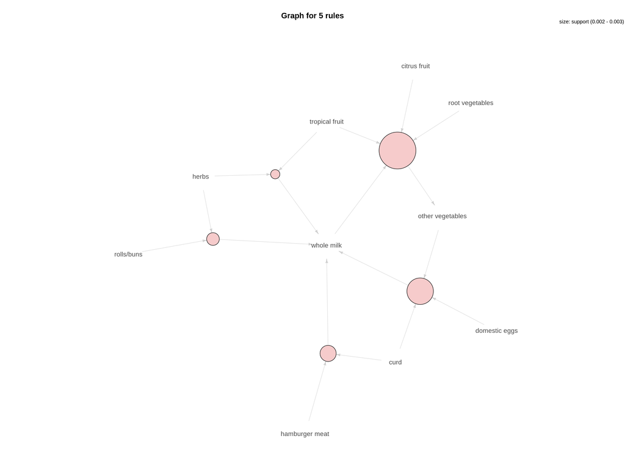

```r
library(arulesViz)
plot(sorted_rules[1:5], method = "graph", shading = NA, interactive = F)
```

Perhaps “sometimes rules with length greater than 3 may not be interesting for client” Let’s say we want more concise rules with length not exceeding 3, which can be easily achieved by adding “maxlen” parameter to the apriori function.

```r
rules_maxlen3 <- apriori(data = Groceries, parameter = list(supp = 0.001, conf = 0.8, maxlen = 3), control = list(verbose = F))
inspect(rules_maxlen3)
```

```
##      lhs                         rhs                support confidence lift count
## [1]  {liquor,
##       red/blush wine}         => {bottled beer}      0.0019       0.90 11.2    19
## [2]  {curd,
##       cereals}                => {whole milk}        0.0010       0.91  3.6    10
## [3]  {yogurt,
##       cereals}                => {whole milk}        0.0017       0.81  3.2    17
## [4]  {butter,
##       jam}                    => {whole milk}        0.0010       0.83  3.3    10
## [5]  {soups,
##       bottled beer}           => {whole milk}        0.0011       0.92  3.6    11
## [6]  {napkins,
##       house keeping products} => {whole milk}        0.0013       0.81  3.2    13
## [7]  {whipped/sour cream,
##       house keeping products} => {whole milk}        0.0012       0.92  3.6    12
## [8]  {pastry,
##       sweet spreads}          => {whole milk}        0.0010       0.91  3.6    10
## [9]  {turkey,
##       curd}                   => {other vegetables}  0.0012       0.80  4.1    12
## [10] {rice,
##       sugar}                  => {whole milk}        0.0012       1.00  3.9    12
## [11] {butter,
##       rice}                   => {whole milk}        0.0015       0.83  3.3    15
## [12] {domestic eggs,
##       rice}                   => {whole milk}        0.0011       0.85  3.3    11
## [13] {rice,
##       bottled water}          => {whole milk}        0.0012       0.92  3.6    12
## [14] {yogurt,
##       rice}                   => {other vegetables}  0.0019       0.83  4.3    19
## [15] {oil,
##       mustard}                => {whole milk}        0.0012       0.86  3.4    12
## [16] {canned fish,
##       hygiene articles}       => {whole milk}        0.0011       1.00  3.9    11
## [17] {herbs,
##       fruit/vegetable juice}  => {other vegetables}  0.0012       0.80  4.1    12
## [18] {herbs,
##       shopping bags}          => {other vegetables}  0.0019       0.83  4.3    19
## [19] {tropical fruit,
##       herbs}                  => {whole milk}        0.0023       0.82  3.2    23
## [20] {herbs,
##       rolls/buns}             => {whole milk}        0.0024       0.80  3.1    24
## [21] {pickled vegetables,
##       chocolate}              => {whole milk}        0.0012       0.86  3.4    12
## [22] {grapes,
##       onions}                 => {other vegetables}  0.0011       0.92  4.7    11
## [23] {meat,
##       margarine}              => {other vegetables}  0.0017       0.85  4.4    17
## [24] {hard cheese,
##       oil}                    => {other vegetables}  0.0011       0.92  4.7    11
## [25] {onions,
##       butter milk}            => {other vegetables}  0.0013       0.81  4.2    13
## [26] {pork,
##       butter milk}            => {other vegetables}  0.0018       0.86  4.4    18
## [27] {onions,
##       waffles}                => {other vegetables}  0.0012       0.80  4.1    12
## [28] {hamburger meat,
##       curd}                   => {whole milk}        0.0025       0.81  3.2    25
## [29] {hamburger meat,
##       bottled beer}           => {whole milk}        0.0017       0.81  3.2    17
```

Redundancies

- Rules might be repeating with different combinations with similar support and confidence values e.g. {A,B} -> {C}, {A,C} -> {B}
- every subset of a frequent itemset is also frequent (Downward closure property)

We can check and remove the redundant rules by using below code snippet

```r
sum(is.redundant(sorted_rules))
```

```
## [1] 18
```

```r
sorted_unique_rules <- sorted_rules[!is.redundant(sorted_rules)]
sum(is.redundant(sorted_unique_rules))
```

```
## [1] 0
```

```r
sum(is.redundant(rules_maxlen3))
```

```
## [1] 0
```

## Targetting items

Now that we know to generate rules and limit the output.

Let’s say we want to target items and generate rules.

Two types of targets which the client might be interested in, let us explore those by using an example of “whole milk” * What are customer likely to buy before buying “whole milk” * What are customer likely to buy if they purchase “whole milk”

essentially you are asking will i be able to set my lhs, rhs or both in my rules?

well! Lets look at the first target condition ** What are customer likely to buy before buying “whole milk” **

```r
target_rules1 <- apriori(data = Groceries, parameter = list(supp = 0.001, conf = 0.8, minlen = 2), appearance = list(rhs = "whole milk"), control = list(verbose = F))

sorted_target_rules1 <- sort(target_rules1, by = "confidence", decreasing = T)
inspect(sorted_target_rules1[1:10])
```

```
##      lhs                     rhs          support confidence lift count
## [1]  {rice,
##       sugar}              => {whole milk}  0.0012          1  3.9    12
## [2]  {canned fish,
##       hygiene articles}   => {whole milk}  0.0011          1  3.9    11
## [3]  {root vegetables,
##       butter,
##       rice}               => {whole milk}  0.0010          1  3.9    10
## [4]  {root vegetables,
##       whipped/sour cream,
##       flour}              => {whole milk}  0.0017          1  3.9    17
## [5]  {butter,
##       soft cheese,
##       domestic eggs}      => {whole milk}  0.0010          1  3.9    10
## [6]  {pip fruit,
##       butter,
##       hygiene articles}   => {whole milk}  0.0010          1  3.9    10
## [7]  {root vegetables,
##       whipped/sour cream,
##       hygiene articles}   => {whole milk}  0.0010          1  3.9    10
## [8]  {pip fruit,
##       root vegetables,
##       hygiene articles}   => {whole milk}  0.0010          1  3.9    10
## [9]  {cream cheese ,
##       domestic eggs,
##       sugar}              => {whole milk}  0.0011          1  3.9    11
## [10] {curd,
##       domestic eggs,
##       sugar}              => {whole milk}  0.0010          1  3.9    10
```

** What are customer likely to buy if they purchase “whole milk” **

```r
target_rules2 <- apriori(data = Groceries, parameter = list(supp = 0.001, conf = 0.15, minlen = 2), appearance = list(lhs = "whole milk"), control = list(verbose = F))

sorted_target_rules2 <- sort(target_rules2, by = "confidence", decreasing = T)
inspect(sorted_target_rules2)
```

```
##     lhs             rhs                support confidence lift count
## [1] {whole milk} => {other vegetables} 0.075   0.29       1.5  736
## [2] {whole milk} => {rolls/buns}       0.057   0.22       1.2  557
## [3] {whole milk} => {yogurt}           0.056   0.22       1.6  551
## [4] {whole milk} => {root vegetables}  0.049   0.19       1.8  481
## [5] {whole milk} => {tropical fruit}   0.042   0.17       1.6  416
## [6] {whole milk} => {soda}             0.040   0.16       0.9  394
```

```r
length(sorted_target_rules2)
```

```
## [1] 6
```

## Visualization

- Visualizing the rules using a graph

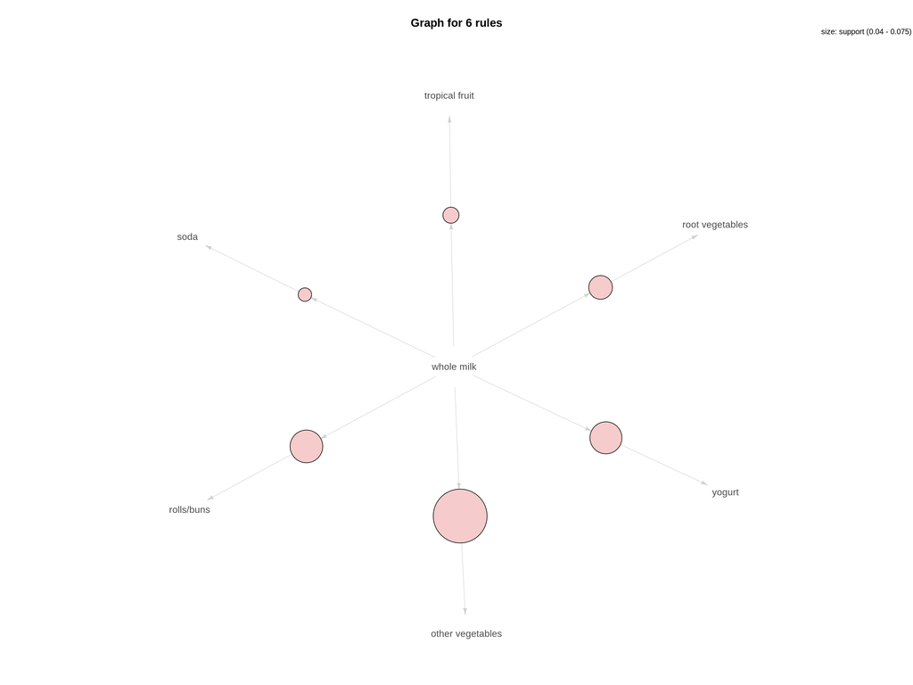

```r
plot(sorted_target_rules2[1:6], method = "graph", shading = NA, interactive = F)
```